# portfolio-2-tidy-tues-bees

Elayna Seago

2/25/2022

## R Markdown

My goals for my bee colony portfolio project are to: 1) get practice using Tidy Tuesday data 2) determine what 10 states/times experienced the greatest loss in colony numbers over a 3 month period. 3) make a graph for the stressors in each of those states in their worst year.

## the cleaning of this data was done using the code provided by tidy tuesday bee data

```r
colony <- readr::read_csv('https://raw.githubusercontent.com/rfordatascience/tidytuesday/master/data/2022/2022-01-11/colony.csv')
stressor <- readr::read_csv('https://raw.githubusercontent.com/rfordatascience/tidytuesday/master/data/2022/2022-01-11/stressor.csv')
library(rvest)
library(tidyverse)
library(fs)
```

```r
# download site
#url <- "https://usda.library.cornell.edu/concern/publications/rn301137d?locale=en"
```

```r
max_colony_loss <- colony %>%
  arrange(desc(colony_lost_pct)) %>%
  slice(1:10)

max_colony_loss
```

```
## # A tibble: 10 × 10
##     year months           state  colony_n colony_max colony_lost colony_lost_pct
##    <dbl> <chr>            <chr>     <dbl>      <dbl>       <dbl>           <dbl>
##  1  2018 January-March    New M…     7500       7500        3900              52
##  2  2015 January-March    Ohio      18000      22000       10500              48
##  3  2016 January-March    Oklah…     6000       6000        2900              48
##  4  2020 April-June       Alaba…     8500       8500        4100              48
##  5  2017 January-March    Massa…     3300       3300        1500              45
##  6  2015 January-March    Maryl…     7500      10000        4100              41
##  7  2015 January-March    Illin…     6000      10500        4200              40
##  8  2015 October-December Kansas     8500       8500        3400              40
##  9  2015 January-March    Kentu…     7500      10500        4100              39
## 10  2017 January-March    New M…     5500       5500        2100              38
## # … with 3 more variables: colony_added <dbl>, colony_reno <dbl>,
## #   colony_reno_pct <dbl>
```

#fix this graph-only 1 new mexico

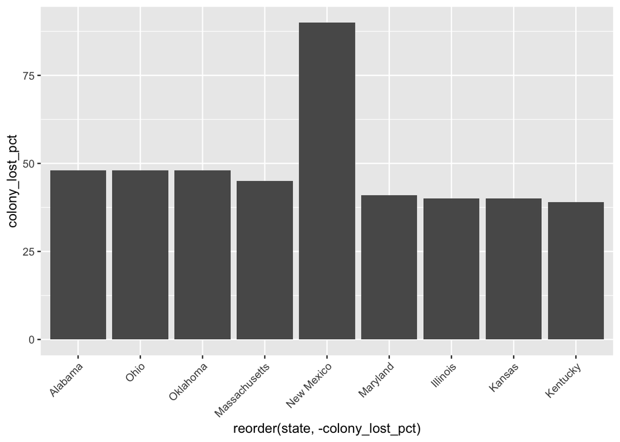

```r
max_colony_loss%>%
  ggplot(aes(x = reorder(state , -colony_lost_pct) , y = colony_lost_pct)) +
  geom_bar(stat = "identity") +
  theme(axis.text.x = element_text(angle = 45, vjust = 1, hjust=1))
```

After making this graph I realized I need to glue state, month, and year together because otherwise New Mexico is very misleading.

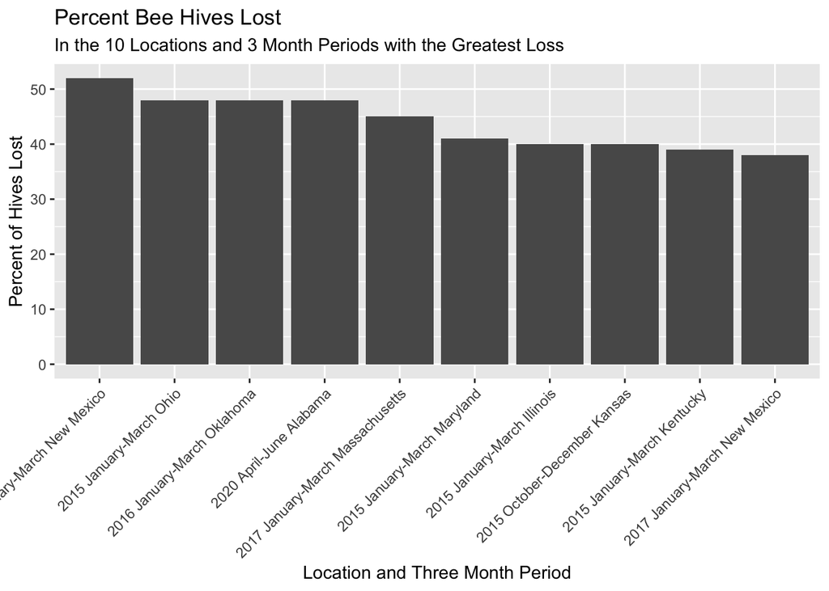

```r
library(glue)

max_colony_loss %>%
  mutate(
    time_place = glue("{year} {months} {state}")
  ) %>%
  ggplot(aes(x = reorder(time_place , -colony_lost_pct) , y = colony_lost_pct)) +
  geom_bar(stat = "identity") +
  theme(axis.text.x = element_text(angle = 45, vjust = 1, hjust=1)) +
  labs(x = "Location and Three Month Period" , y = "Percent of Hives Lost" , title = "Percent Bee Hives Lost" , subtitle = "In the 10 Locations and 3 Month Periods with the Greatest Loss")
```

### Goal number 3

I think it will be helpful to join the two data sets for this portion.

```r
colonies_stressors <- full_join(colony, stressor, by =  c("year" , "months" , "state"))

colonies_stressors
```

```
## # A tibble: 7,332 × 12
##     year months        state   colony_n colony_max colony_lost colony_lost_pct
##    <dbl> <chr>         <chr>      <dbl>      <dbl>       <dbl>           <dbl>
##  1  2015 January-March Alabama     7000       7000        1800              26
##  2  2015 January-March Alabama     7000       7000        1800              26
##  3  2015 January-March Alabama     7000       7000        1800              26
##  4  2015 January-March Alabama     7000       7000        1800              26
##  5  2015 January-March Alabama     7000       7000        1800              26
##  6  2015 January-March Alabama     7000       7000        1800              26
##  7  2015 January-March Arizona    35000      35000        4600              13
##  8  2015 January-March Arizona    35000      35000        4600              13
##  9  2015 January-March Arizona    35000      35000        4600              13
## 10  2015 January-March Arizona    35000      35000        4600              13
## # … with 7,322 more rows, and 5 more variables: colony_added <dbl>,
## #   colony_reno <dbl>, colony_reno_pct <dbl>, stressor <chr>, stress_pct <dbl>
```

#re-do the filter thing I did before to get the top 10 worst sections and do the glueing-sliced for 1:60 because it is the long version of data # initially I thought I had made some sort of mistake because the pct stressors adds to above 100% in some cases, but then I realized one hive can have multiple stressors. So I think this is actually correct after all. however, this may make the graph confusing to others. It would be nice if there was a different stressor option that said “multiple stressors” or something.

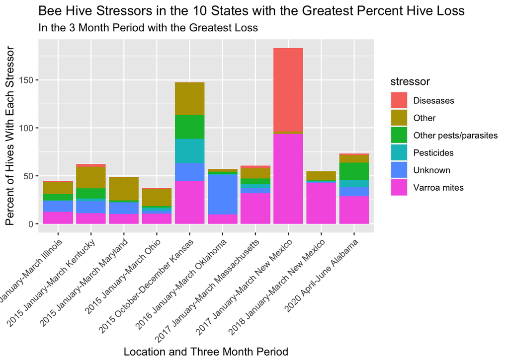

```r
max_colony_loss_stress <- colonies_stressors %>%
  arrange(desc(colony_lost_pct)) %>%
  slice(1:60)

max_colony_loss_stress %>%
  mutate(
    time_place = glue("{year} {months} {state}")
  ) %>%
  ggplot(aes(x = time_place , y = stress_pct , fill = stressor)) +
  geom_bar(stat = "identity") +
  theme(axis.text.x = element_text(angle = 45, vjust = 1, hjust=1)) +
  labs(x = "Location and Three Month Period" , y = "Percent of Hives With Each Stressor" , title = "Bee Hive Stressors in the 10 States with the Greatest Percent Hive Loss" , subtitle = "In the 3 Month Period with the Greatest Loss")
```

```r
max_colony_loss_stress
```

```
## # A tibble: 60 × 12
##     year months        state     colony_n colony_max colony_lost colony_lost_pct
##    <dbl> <chr>         <chr>        <dbl>      <dbl>       <dbl>           <dbl>
##  1  2018 January-March New Mexi…     7500       7500        3900              52
##  2  2018 January-March New Mexi…     7500       7500        3900              52
##  3  2018 January-March New Mexi…     7500       7500        3900              52
##  4  2018 January-March New Mexi…     7500       7500        3900              52
##  5  2018 January-March New Mexi…     7500       7500        3900              52
##  6  2018 January-March New Mexi…     7500       7500        3900              52
##  7  2015 January-March Ohio         18000      22000       10500              48
##  8  2015 January-March Ohio         18000      22000       10500              48
##  9  2015 January-March Ohio         18000      22000       10500              48
## 10  2015 January-March Ohio         18000      22000       10500              48
## # … with 50 more rows, and 5 more variables: colony_added <dbl>,
## #   colony_reno <dbl>, colony_reno_pct <dbl>, stressor <chr>, stress_pct <dbl>
```